# Marketing Analytics & Social Media Intelligence (337090)

Julia Zerrweck, Sanja Perovic

18.11.2020

```r
library(tidyverse)
library(tidymodels)
library(tidyr)
library(psych)
library(dplyr)
```

# Aufgabe 1: Regression I

## Daten vorbereiten

```r
library(readr)
auto <- read_csv("https://raw.githubusercontent.com/sanjapero/Clustering/master/Marketing%20Analytics/auto.csv")
```

```r
glimpse(auto)
```

```
## Rows: 397
## Columns: 9
## $ mpg          <dbl> 18, 15, 18, 16, 17, 15, 14, 14, 14, 15, 15, 14, 15, 14, …
## $ cylinders    <dbl> 8, 8, 8, 8, 8, 8, 8, 8, 8, 8, 8, 8, 8, 8, 4, 6, 6, 6, 4,…
## $ displacement <dbl> 307, 350, 318, 304, 302, 429, 454, 440, 455, 390, 383, 3…
## $ horsepower   <chr> "130", "165", "150", "150", "140", "198", "220", "215", …
## $ weight       <dbl> 3504, 3693, 3436, 3433, 3449, 4341, 4354, 4312, 4425, 38…
## $ acceleration <dbl> 12.0, 11.5, 11.0, 12.0, 10.5, 10.0, 9.0, 8.5, 10.0, 8.5,…
## $ year         <dbl> 70, 70, 70, 70, 70, 70, 70, 70, 70, 70, 70, 70, 70, 70, …
## $ origin       <dbl> 1, 1, 1, 1, 1, 1, 1, 1, 1, 1, 1, 1, 1, 1, 3, 1, 1, 1, 3,…
## $ name         <chr> "chevrolet chevelle malibu", "buick skylark 320", "plymo…
```

```r
auto$horsepower <-  as.numeric(auto$horsepower)
auto$origin <- as.factor(auto$origin)
auto$name <- as.factor(auto$name)

anyNA(auto, recursive = FALSE)
```

```
## [1] TRUE
```

```r
auto <- drop_na(auto, horsepower)
describe(auto)
```

```
##              vars   n    mean     sd  median trimmed    mad  min    max  range
## mpg             1 392   23.45   7.81   22.75   22.99   8.60    9   46.6   37.6
## cylinders       2 392    5.47   1.71    4.00    5.35   0.00    3    8.0    5.0
## displacement    3 392  194.41 104.64  151.00  183.83  90.44   68  455.0  387.0
## horsepower      4 392  104.47  38.49   93.50   99.82  28.91   46  230.0  184.0
## weight          5 392 2977.58 849.40 2803.50 2916.94 948.12 1613 5140.0 3527.0
## acceleration    6 392   15.54   2.76   15.50   15.48   2.52    8   24.8   16.8
## year            7 392   75.98   3.68   76.00   75.97   4.45   70   82.0   12.0
## origin*         8 392    1.58   0.81    1.00    1.47   0.00    1    3.0    2.0
## name*           9 392  148.35  89.53  148.50  148.03 119.35    1  304.0  303.0
##              skew kurtosis    se
## mpg          0.45    -0.54  0.39
## cylinders    0.50    -1.40  0.09
## displacement 0.70    -0.79  5.29
## horsepower   1.08     0.65  1.94
## weight       0.52    -0.83 42.90
## acceleration 0.29     0.41  0.14
## year         0.02    -1.18  0.19
## origin*      0.91    -0.86  0.04
## name*        0.03    -1.25  4.52
```

## 1.a) Lineare Regression

Use the regression function (lm) to perform a linear regression with mpg as the response and horsepower as the predictor. Comment on the output. In particular:

```r
linear_lm <-
  linear_reg() %>%
  set_engine("lm") %>%
  set_mode(mode = "regression")
```

### Data splitting

```r
set.seed(42)

auto_split <- initial_split(auto)
auto_train <-  training(auto_split)
auto_test <- testing(auto_split)
```

```r
set.seed(42)

cv_folds <-
  vfold_cv(auto_train,
           v = 10,
           strata = mpg,
           breaks = 4)
```

### 1.a)1.)

Is there a statistically significant relationship between the predictor and the response?

```r
linear_lm_train = lm(mpg ~ horsepower, data=auto)
summary(linear_lm_train)
```

```
##
## Call:
## lm(formula = mpg ~ horsepower, data = auto)
##
## Residuals:
##      Min       1Q   Median       3Q      Max
## -13.5710  -3.2592  -0.3435   2.7630  16.9240
##
## Coefficients:
##              Estimate Std. Error t value Pr(>|t|)
## (Intercept) 39.935861   0.717499   55.66   <2e-16 ***
## horsepower  -0.157845   0.006446  -24.49   <2e-16 ***
## ---
## Signif. codes:  0 '***' 0.001 '**' 0.01 '*' 0.05 '.' 0.1 ' ' 1
##
## Residual standard error: 4.906 on 390 degrees of freedom
## Multiple R-squared:  0.6059, Adjusted R-squared:  0.6049
## F-statistic: 599.7 on 1 and 390 DF,  p-value: < 2.2e-16
```

Ja, da der p-Wert von 2.2e-16 nahe 0 ist.

### 1.a.)2.)

How strong is the relationship between the predictor and the response?

Kann man ablesen beim Adjusted R-squared welcher in diesem Fall 0,6049 beträgt. Dies bedeutet dass 60% der Varianz durch horsepower erklärt wird.

### 1.a.)3.)

Is the relationship between the predictor and the response positive or negative?

Negativ, da je mehr PS ein Auto hat, desto linearer wird die Kraftstoffeffizienz. Kann man am negativen Horsepower-Koeffizienten ablesen.

### 1.a.)4.)

Provide an interpretation of the coefficients in the model. Describe their meaning in the regression method as well as their specific meaning in this example (i.e. the cuasal relationship between horsepower and mpg).

Der Steigungskoeffizient von Horsepower beträgt -0.157845 was bedeutet, dass mit jedem Horsepower mehr, sinkt MPG um ca. 0.15 Einheiten. Intercept ist nicht möglich, denn mit 0PS ist auch kein mpg möglich. (Intercept ist der Mittelwert von Y (mpg) wenn X (hs)=0 ist.)

### 1.a.)5.)

What is the predicted mpg associated with a horsepower of 98?

```r
predict(linear_lm_train,data.frame(horsepower=c(98)),interval="prediction")
```

```
##        fit     lwr      upr
## 1 24.46708 14.8094 34.12476
```

Die vorhergesagte mpg, mit einer Horsepower von 98, beträgt ungefähr 24,47. Wir sind zu 95% sicher, dass MPG eines Autos, mit einer Leistung von 98 PS, zwischen 14,81 und 34,12 liegt.

### 1.a.)6.)

What is the root mean squared error (RMSE) of your model? Give an interpretation of the finding [4 point]

```r
lm_results <-
  linear_lm %>%
  fit_resamples(
    mpg ~ horsepower,
    resamples = cv_folds
    )
```

```r
lm_results %>%
  collect_metrics(summarize = TRUE)
```

```
## # A tibble: 2 x 5
##   .metric .estimator  mean     n std_err
##   <chr>   <chr>      <dbl> <int>   <dbl>
## 1 rmse    standard   4.79     10  0.214
## 2 rsq     standard   0.630    10  0.0274
```

Der mean-RMSE beträgt 4.787, wad bedeutet, dass die tatsächlichen MPG sich im Durchschnitt um 4,787 Einheiten von den Vorhersagen der Regression unterscheiden.

### 1.b.)

Plot the response and the predictor. Display the least squares regression line.

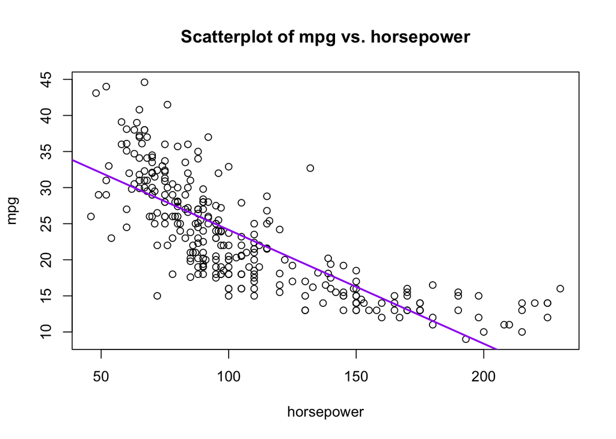

```r
plot(auto_train$horsepower, auto_train$mpg,
     main = "Scatterplot of mpg vs. horsepower",
     xlab = "horsepower",
     ylab = "mpg",
     col = "black")
abline(linear_lm_train, lwd = 2, lty = 1, col = "purple")
```

### 1.c.)

Use a boosted decision tree to perform a regression with mpg as the response and horsepower as the predictor [4 points].

```r
library(parsnip)
```

```r
bdt_model <-
  boost_tree() %>%
  set_engine("xgboost") %>%
  set_mode("regression")
```

```r
bdt_model_fit <-
  bdt_model %>%
  fit(mpg ~ horsepower, data = auto_train)
```

```
## [17:39:45] WARNING: amalgamation/../src/objective/regression_obj.cu:174: reg:linear is now deprecated in favor of reg:squarederror.
```

### 1.c.)1.)

What is the predicted mpg associated with a horsepower of 98?

```r
predict(bdt_model_fit,data.frame(horsepower=c(98)))
```

```
## # A tibble: 1 x 1
##   .pred
##   <dbl>
## 1  20.2
```

Die vorhergesagte MPG mit Horsepower von 98 beträgt einen Wert von 20,17.

### 1.c.)2.)

What is the root mean squared error (RMSE) of your model? Compare the finding with the linear regression model.

```r
bdt_results <-
  bdt_model %>%
  fit_resamples(
    mpg ~ horsepower,
    resamples = cv_folds
    )
```

```r
bdt_results %>%
  collect_metrics(summarize = TRUE)
```

```
## # A tibble: 2 x 5
##   .metric .estimator  mean     n std_err
##   <chr>   <chr>      <dbl> <int>   <dbl>
## 1 rmse    standard   4.36     10  0.219
## 2 rsq     standard   0.692    10  0.0202
```

Der RMSE beträgt 4,365, was bdeutetd, dass die tatsächlichen MPG sich im Durchschnitt um 4,365 Einheiten von den Vorhersagen des Boosted Tree Models unterscheiden. Wenn man diesen Wert mit dem der linearen Regression vergleicht (4,787) erkennt man, dass man in diesem Fall das Boosted Decision Tree Model verwendet werden sollte, da dieser Wert deutlich niedriger ist. (4,365 < 4,787)

# Aufgabe 2: Regression II

This question involves the use of multiple linear regression on the car data set. ## Daten vorbereiten

```r
auto <- read.csv("https://raw.githubusercontent.com/sanjapero/Clustering/master/Marketing%20Analytics/auto.csv")
```

```r
glimpse(auto)
```

```
## Rows: 397
## Columns: 9
## $ mpg          <dbl> 18, 15, 18, 16, 17, 15, 14, 14, 14, 15, 15, 14, 15, 14, …
## $ cylinders    <int> 8, 8, 8, 8, 8, 8, 8, 8, 8, 8, 8, 8, 8, 8, 4, 6, 6, 6, 4,…
## $ displacement <dbl> 307, 350, 318, 304, 302, 429, 454, 440, 455, 390, 383, 3…
## $ horsepower   <chr> "130", "165", "150", "150", "140", "198", "220", "215", …
## $ weight       <int> 3504, 3693, 3436, 3433, 3449, 4341, 4354, 4312, 4425, 38…
## $ acceleration <dbl> 12.0, 11.5, 11.0, 12.0, 10.5, 10.0, 9.0, 8.5, 10.0, 8.5,…
## $ year         <int> 70, 70, 70, 70, 70, 70, 70, 70, 70, 70, 70, 70, 70, 70, …
## $ origin       <int> 1, 1, 1, 1, 1, 1, 1, 1, 1, 1, 1, 1, 1, 1, 3, 1, 1, 1, 3,…
## $ name         <chr> "chevrolet chevelle malibu", "buick skylark 320", "plymo…
```

```r
sum(is.na(auto))
```

```
## [1] 0
```

```r
auto <- drop_na(auto)
```

```r
summary(auto)
```

```
##       mpg          cylinders      displacement    horsepower
##  Min.   : 9.00   Min.   :3.000   Min.   : 68.0   Length:397
##  1st Qu.:17.50   1st Qu.:4.000   1st Qu.:104.0   Class :character
##  Median :23.00   Median :4.000   Median :146.0   Mode  :character
##  Mean   :23.52   Mean   :5.458   Mean   :193.5
##  3rd Qu.:29.00   3rd Qu.:8.000   3rd Qu.:262.0
##  Max.   :46.60   Max.   :8.000   Max.   :455.0
##      weight      acceleration        year           origin
##  Min.   :1613   Min.   : 8.00   Min.   :70.00   Min.   :1.000
##  1st Qu.:2223   1st Qu.:13.80   1st Qu.:73.00   1st Qu.:1.000
##  Median :2800   Median :15.50   Median :76.00   Median :1.000
##  Mean   :2970   Mean   :15.56   Mean   :75.99   Mean   :1.574
##  3rd Qu.:3609   3rd Qu.:17.10   3rd Qu.:79.00   3rd Qu.:2.000
##  Max.   :5140   Max.   :24.80   Max.   :82.00   Max.   :3.000
##      name
##  Length:397
##  Class :character
##  Mode  :character
##
##
##
```

```r
auto$horsepower <- as.double(auto$horsepower)
```

```r
set.seed(42)
auto_split <- initial_split(auto)
auto_train <-  training(auto_split)
auto_test <- testing(auto_split)
```

```r
set.seed(42)

cv_folds <-
 vfold_cv(auto_train,
           v = 10,
           strata = mpg,
           breaks = 4)
```

### 2.a.)

Produce scatterplots to analyze the relationships between the variables in the data set. Interpret the findings.

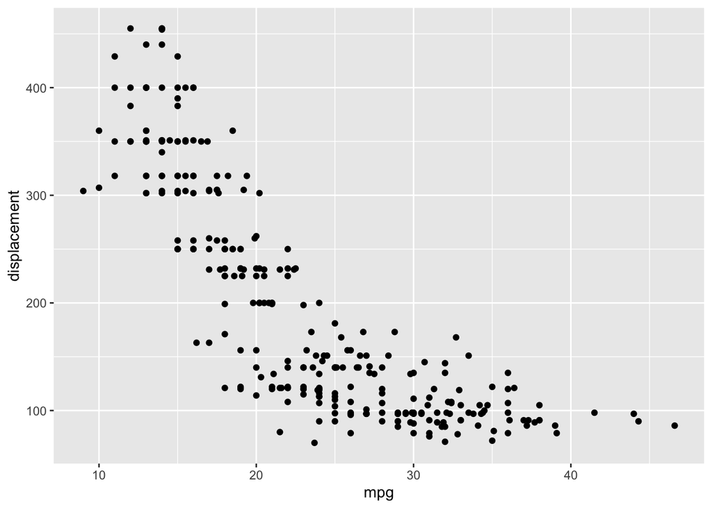

```r
ggplot(auto_train, aes(x = mpg, y = displacement)) +
  geom_point()
```

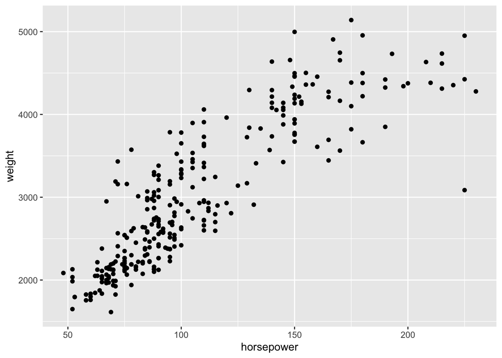

```r
ggplot(auto_train, aes(x = horsepower, y = weight)) +
  geom_point()
```

Je höher die PS desto schwerer ist das Auto.

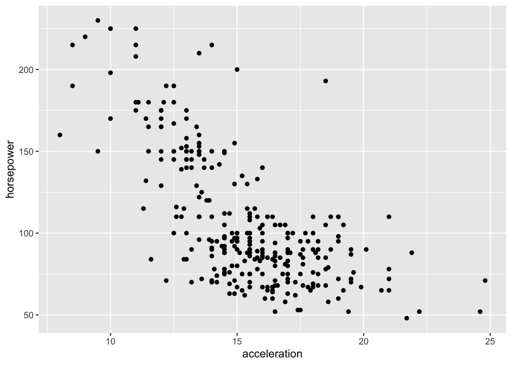

```r
ggplot(auto_train, aes(x = acceleration, y = horsepower)) +
  geom_point()
```

Je mehr PS desto geringer die Beschleunigungszeit.

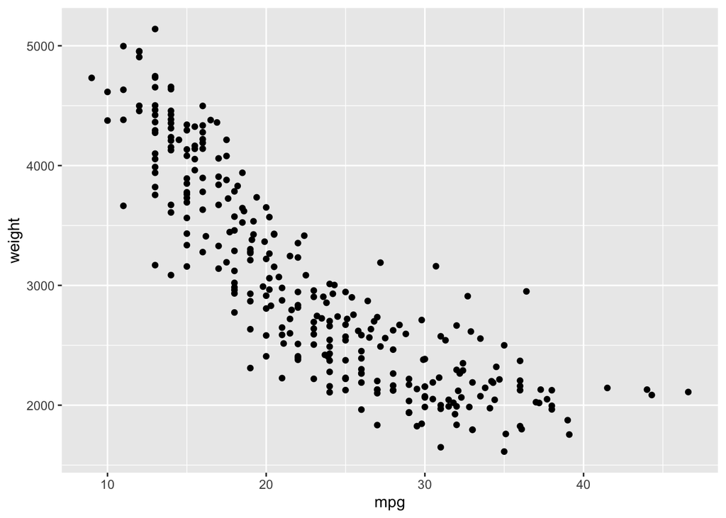

```r
ggplot(auto_train, aes(x = mpg, y = weight)) +
  geom_point()
```

Je schwerer ein Auto ist desto höher ist der Treibstoffverbrauch.

### 2.b.)

Compute the correlations between all variables. You will need to exclude the name variable, which is qualitative. Comment on your findings.

```r
cor(auto_train[, !(names(auto_train)=="name")])
```

```
##                     mpg  cylinders displacement horsepower     weight
## mpg           1.0000000 -0.8015382   -0.8295284         NA -0.8550156
## cylinders    -0.8015382  1.0000000    0.9500259         NA  0.9083341
## displacement -0.8295284  0.9500259    1.0000000         NA  0.9350710
## horsepower           NA         NA           NA          1         NA
## weight       -0.8550156  0.9083341    0.9350710         NA  1.0000000
## acceleration  0.3937791 -0.5069359   -0.5472213         NA -0.4136245
## year          0.5832980 -0.3457817   -0.3966606         NA -0.3438521
## origin        0.5705524 -0.5666716   -0.6124164         NA -0.5847133
##              acceleration       year     origin
## mpg             0.3937791  0.5832980  0.5705524
## cylinders      -0.5069359 -0.3457817 -0.5666716
## displacement   -0.5472213 -0.3966606 -0.6124164
## horsepower             NA         NA         NA
## weight         -0.4136245 -0.3438521 -0.5847133
## acceleration    1.0000000  0.2713951  0.2006236
## year            0.2713951  1.0000000  0.2071873
## origin          0.2006236  0.2071873  1.0000000
```

Die Variablen Displacement und Cylinder sind am stärksten voneinander abhängig. Die Variablen Displacement und Weight sind auch sehr stark voneinander abhängig. Die Variable Acceleration und Origin sind am wenigsten voneinander abhängig. Die Variablen Year und Origin sind auch sehr wenig voneinander abhängig.

### 2.c.)

Perform a multiple linear regression with mpg as the response and all other variables except name as the predictors. In particular:

```r
mlr <- lm(mpg ~ .-name, auto_train)
summary(mlr)
```

```
##
## Call:
## lm(formula = mpg ~ . - name, data = auto_train)
##
## Residuals:
##    Min     1Q Median     3Q    Max
## -8.247 -1.899  0.132  1.668 13.825
##
## Coefficients:
##                Estimate Std. Error t value Pr(>|t|)
## (Intercept)  -10.737443   5.158158  -2.082 0.038261 *
## cylinders     -0.616461   0.356842  -1.728 0.085145 .
## displacement   0.011572   0.008009   1.445 0.149571
## horsepower    -0.015736   0.014561  -1.081 0.280743
## weight        -0.005659   0.000723  -7.827 9.67e-14 ***
## acceleration  -0.054535   0.111378  -0.490 0.624764
## year           0.694142   0.057584  12.054  < 2e-16 ***
## origin         1.130084   0.311073   3.633 0.000332 ***
## ---
## Signif. codes:  0 '***' 0.001 '**' 0.01 '*' 0.05 '.' 0.1 ' ' 1
##
## Residual standard error: 3.166 on 287 degrees of freedom
##   (3 observations deleted due to missingness)
## Multiple R-squared:  0.835,  Adjusted R-squared:  0.831
## F-statistic: 207.5 on 7 and 287 DF,  p-value: < 2.2e-16
```

#### 2.c.)1.)

Is there a relationship between the predictors and the response?

Ja, mit einem p-Wert von 2.2e-16.

#### 2.c.)2.)

Which predictors appear to have a statistically significant relationship to the response?

Wird rausgefunden, indem man die p-Werte, die der t-Statistik jedes Prädiktors zugeordnet sind überprüft. “weight”, “year” und “origin” haben eine statistisch signifikante Beziehung, während “cylinders”, “displacement”, “horsepower” und “acceleration” keine statistisch signifikante Beziehung haben.

#### 2.c.)3.)

What does the coefficient for the year variable suggest?

#### 2.c.)4.)

What is the predicted mpg associated with a horsepower of 98?

```r
predict(mlr, data.frame(cylinders=c(4), displacement=(113), horsepower=c(98), weight=c(2372), acceleration=c(15), year=c(70), origin=c(3), name=c("toyota corona mark ii")),interval="prediction")
```

```
##        fit      lwr      upr
## 1 24.30204 17.97883 30.62526
```

Wenn Horsepower = 98 ist, dann haben wir einen mpg Wert von 24.3

#### 2.c.)5.)

What is the root mean squared error (MSE) of your model?

```r
second_lm_results <-
  linear_lm %>%
  fit_resamples(
    mpg ~ .-name,
    resamples = cv_folds
    )
```

```r
second_lm_results %>%
  collect_metrics(summarize = TRUE)
```

```
## # A tibble: 2 x 5
##   .metric .estimator  mean     n std_err
##   <chr>   <chr>      <dbl> <int>   <dbl>
## 1 rmse    standard   3.17     10  0.196
## 2 rsq     standard   0.836    10  0.0176
```

Mean-RMSE: 3,165 Dies bedeutet, dass die tatsächlichen mpg sich im Durchschnitt um 3,165 Einheiten von den Vorhersagen der Regression unterscheiden.

### 2.d.)

Use a boosted decision tree to perform a regression with mpg as the response and all other variables except name as the predictors.

```r
second_bdt_model_fit <-
  bdt_model %>%
  fit(mpg ~ .-name, data = auto_train)
```

```
## [17:39:54] WARNING: amalgamation/../src/objective/regression_obj.cu:174: reg:linear is now deprecated in favor of reg:squarederror.
```

#### 2.d.)1.)

What is the predicted mpg associated with a horsepower of 98?

```r
predict(second_bdt_model_fit,data.frame(cylinders=c(4), displacement=(113), horsepower=c(98), weight=c(2372), acceleration=c(15), year=c(70), origin=c(3), name=c("toyota corona mark ii")))
```

```
## # A tibble: 1 x 1
##   .pred
##   <dbl>
## 1  23.7
```

Bei horsepower von 98 sagt das Modell einen Wert von 23.65 mpg voraus.

#### 2.d.)2.)

What is the root mean squared error (RMSE) of your model? Compare the finding with the linear regression model.

```r
second_bdt_model_fit <-
  bdt_model %>%
  fit_resamples(
    mpg ~ .-name,
    resamples = cv_folds
    )
```

```r
second_bdt_model_fit %>%
  collect_metrics(summarize = TRUE)
```

```
## # A tibble: 2 x 5
##   .metric .estimator  mean     n std_err
##   <chr>   <chr>      <dbl> <int>   <dbl>
## 1 rmse    standard   2.76     10  0.177
## 2 rsq     standard   0.887    10  0.0119
```

Der RMSE ist beim BDT (2.76) deutlich niedriger als beim LM (3.17) und somit präziser.

# Aufgabe 3: Sales Analysis

## Daten vorbereiten

```r
carseats <- read.csv("carseats.csv")
glimpse(carseats)
```

```
## Rows: 400
## Columns: 12
## $ X           <int> 1, 2, 3, 4, 5, 6, 7, 8, 9, 10, 11, 12, 13, 14, 15, 16, 17…
## $ Sales       <dbl> 9.50, 11.22, 10.06, 7.40, 4.15, 10.81, 6.63, 11.85, 6.54,…
## $ CompPrice   <int> 138, 111, 113, 117, 141, 124, 115, 136, 132, 132, 121, 11…
## $ Income      <int> 73, 48, 35, 100, 64, 113, 105, 81, 110, 113, 78, 94, 35, …
## $ Advertising <int> 11, 16, 10, 4, 3, 13, 0, 15, 0, 0, 9, 4, 2, 11, 11, 5, 0,…
## $ Population  <int> 276, 260, 269, 466, 340, 501, 45, 425, 108, 131, 150, 503…
## $ Price       <int> 120, 83, 80, 97, 128, 72, 108, 120, 124, 124, 100, 94, 13…
## $ ShelveLoc   <chr> "Bad", "Good", "Medium", "Medium", "Bad", "Bad", "Medium"…
## $ Age         <int> 42, 65, 59, 55, 38, 78, 71, 67, 76, 76, 26, 50, 62, 53, 5…
## $ Education   <int> 17, 10, 12, 14, 13, 16, 15, 10, 10, 17, 10, 13, 18, 18, 1…
## $ Urban       <chr> "Yes", "Yes", "Yes", "Yes", "Yes", "No", "Yes", "Yes", "N…
## $ US          <chr> "Yes", "Yes", "Yes", "Yes", "No", "Yes", "No", "Yes", "No…
```

```r
drop_na(carseats)
```

[output not shown]

[output cut: 787 more lines]

```r
set.seed(42)

carseats_split <- initial_split(carseats)
carseats_train <-  training(carseats_split)
carseats_test <- testing(carseats_split)

cv_folds <-
  vfold_cv(carseats_train,
           v = 10,
           breaks = 4)
```

### 3.a.)

Fit a multiple regression model to predict Sales using Price, Urban, and US. Use training and test data.

Multiple Regression Model

```r
mrm_salesanalysis <- lm(Sales ~ Price + Urban + US, data = carseats_train)
summary(mrm_salesanalysis)
```

```
##
## Call:
## lm(formula = Sales ~ Price + Urban + US, data = carseats_train)
##
## Residuals:
##     Min      1Q  Median      3Q     Max
## -6.9594 -1.6429 -0.0226  1.5627  6.5090
##
## Coefficients:
##              Estimate Std. Error t value Pr(>|t|)
## (Intercept) 13.439692   0.752162  17.868  < 2e-16 ***
## Price       -0.057629   0.005978  -9.641  < 2e-16 ***
## UrbanYes    -0.165971   0.311164  -0.533    0.594
## USYes        1.329560   0.300622   4.423 1.37e-05 ***
## ---
## Signif. codes:  0 '***' 0.001 '**' 0.01 '*' 0.05 '.' 0.1 ' ' 1
##
## Residual standard error: 2.475 on 296 degrees of freedom
## Multiple R-squared:  0.2715, Adjusted R-squared:  0.2641
## F-statistic: 36.78 on 3 and 296 DF,  p-value: < 2.2e-16
```

### 3.b.)

Provide an interpretation of each coefficient in the model. Be careful — some of the variables in the model are qualitative!

Price: erhöht sich der Preis kommt es zu einem Rückgang der Sales um 57,62 Einheiten. Urban: durchschnittliche Verkauf von Einheiten in städtischen Gebieten um 165,97 Einheiten geringer ist als in ländlichen Gebieten US: in einem US-Geschäft werden durchschnittlich 1329,56 Einheiten mehr verkauft als in einem Nicht-US-Geschäft.

### 3.c.)

For which of the predictors can you reject the null hypothesis H0 : βj = 0?

Sowohl für Price als auch US.

### 3.d.)

Fit a smaller model: On the basis of your response to the previous question, fit a smaller model that only uses the predictors for which there is evidence of association with the outcome (i.e. update your model).

```r
mrm_salesanalysis_smaller <- lm(Sales ~ Price + US, data = carseats_train)
summary(mrm_salesanalysis_smaller)
```

```
##
## Call:
## lm(formula = Sales ~ Price + US, data = carseats_train)
##
## Residuals:
##     Min      1Q  Median      3Q     Max
## -7.0083 -1.6100 -0.0445  1.5411  6.4621
##
## Coefficients:
##              Estimate Std. Error t value Pr(>|t|)
## (Intercept) 13.336866   0.726162  18.366  < 2e-16 ***
## Price       -0.057706   0.005969  -9.668  < 2e-16 ***
## USYes        1.323692   0.300058   4.411 1.44e-05 ***
## ---
## Signif. codes:  0 '***' 0.001 '**' 0.01 '*' 0.05 '.' 0.1 ' ' 1
##
## Residual standard error: 2.472 on 297 degrees of freedom
## Multiple R-squared:  0.2708, Adjusted R-squared:  0.2659
## F-statistic: 55.16 on 2 and 297 DF,  p-value: < 2.2e-16
```

### 3.e.)

How well do the models in a. and d. fit the data?

Eigentlich sind sie in etwa gleich, da der RSE bei unserem neuen Model nur minimal besser abschneidet –> gernigere Fehlerquote bei der Regression. Der R-squared liegt ebenfalls bei beiden bei ca. 27% –> nur dieser Anteil der Streuung der Sales Werte wird durch die Predictors beeinflusst.

### 3.f.)

Use a boosted decision tree to perform the regression in a.

```r
bdt_model <-
  boost_tree() %>%
  set_engine("xgboost") %>%
  set_mode("regression")

bdt_carseats <-
  bdt_model %>%
  fit(Sales ~ Price + Urban + US, data = carseats_train)
```

```
## [17:39:58] WARNING: amalgamation/../src/objective/regression_obj.cu:174: reg:linear is now deprecated in favor of reg:squarederror.
```

#### 3.f.)1.)

What is the root mean squared error (RMSE) of your model? Compare the finding with the linear regression model.

```r
bdt_results_seats <-
  bdt_model %>%
  fit_resamples(
    Sales ~ Price + Urban + US,
    resamples = cv_folds
    )

bdt_results_seats %>%
  collect_metrics(summarize = TRUE)
```

```
## # A tibble: 2 x 5
##   .metric .estimator  mean     n std_err
##   <chr>   <chr>      <dbl> <int>   <dbl>
## 1 rmse    standard   2.70     10  0.0485
## 2 rsq     standard   0.163    10  0.0438
```

RMSE liegt bei 2.703 im Vgl. zum RMSE des linear regression model von 2.475. D.h. das linear model ist hier präziser und sollte angewendet werden. R-squared liegt im Vgl zum linearen Modell nur noch bei 0.163, d.h. dass sogar noch weniger der Sales erklärt werden können, weil man den Anteil der Veränderungen weniger bestimmen kann.

# Aufgabe 4: Gender Analysis

## Daten vorbereiten

```r
responses_df <- read.csv("responses.csv", na.strings = c("", "NA"))
responses_df <- drop_na(responses_df)
responses_df
```

[output not shown]

[output cut: 19329 more lines]

### 4.1.)

Data Exploration

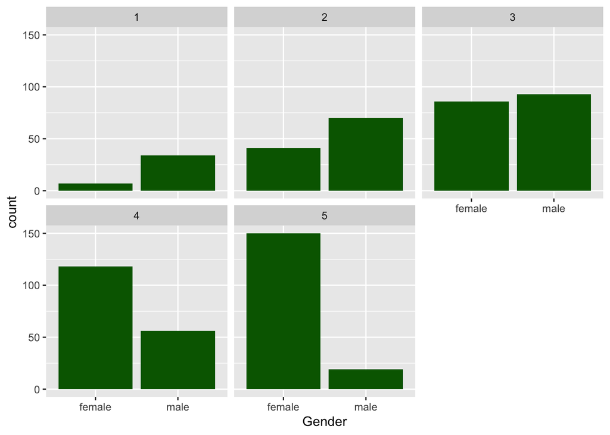

```r
ggplot(responses_df, aes(x=Gender)) +
  geom_bar(position = "dodge", fill= "darkgreen")+
  facet_wrap(~ responses_df$Romantic)
```

Frauen haben im Schnitt eine höhere Tendenz zu romantischen Filmen als Männer.

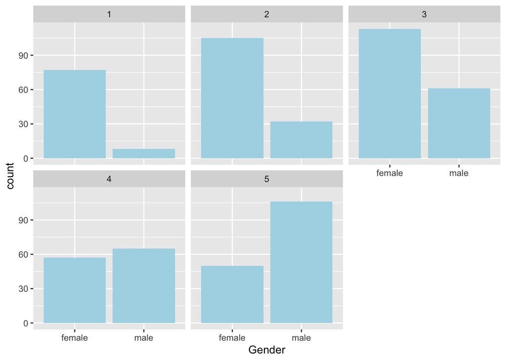

```r
ggplot(responses_df, aes(x=Gender)) +
  geom_bar(position = "dodge", fill= "lightblue")+
  facet_wrap(~ responses_df$War)
```

Männer schauen sich im Schnitt eher Kriegsfilme an als Frauen.

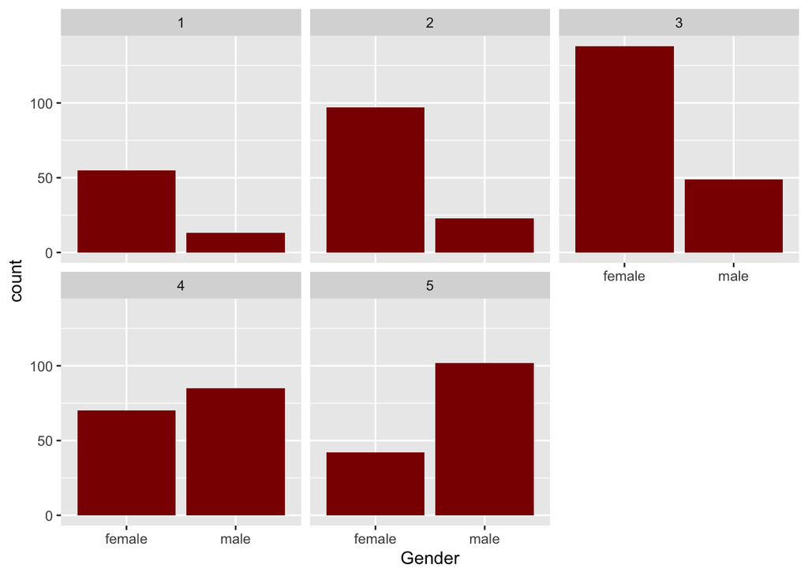

```r
ggplot(responses_df, aes(x=Gender)) +
  geom_bar(position = "dodge", fill= "darkred")+
  facet_wrap(~ responses_df$Science.and.technology)
```

Ein besonders hohes Interesse besteht tatsächlich nur bei Männern, während Frauen eher ein mittleres bis gar kein Interesse daran haben.

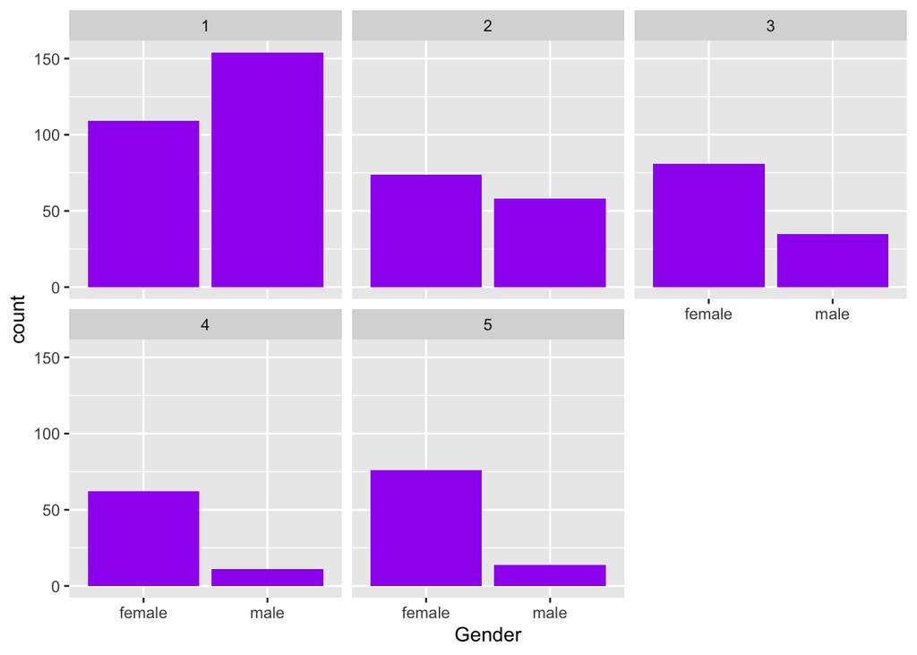

```r
ggplot(responses_df, aes(x=Gender)) +
  geom_bar(position = "dodge", fill= "purple")+
  facet_wrap(~ responses_df$Dancing)
```

Man kann erkennen, dass Männer tatsächlich eher abgeneigt sind zu tanzen als Frauen. Besonders im Bereich “1” sind viele Männer.

## 4.2

### Fit models

Fit two models with (at least four) predictor variables of your choice.

```r
responses_df$Gender <- as.factor(responses_df$Gender)
```

```r
gender_df <- subset(responses_df, select=c(Gender, Romantic, War, Science.and.technology, Dancing))
```

```r
set.seed(42)

gender_split <- initial_split(gender_df)
gender_train <- training(gender_split)
gender_test <- testing(gender_split)

set.seed(42)

cv_folds_gender <-
  vfold_cv(gender_train,
           v = 10,
           strata = Gender,
           breaks = 4)
```

### Create Recipe

```r
gender_recipe <-
  recipe(Gender ~ .,
         data = gender_train)

summary(gender_recipe)
```

```
## # A tibble: 5 x 4
##   variable               type    role      source
##   <chr>                  <chr>   <chr>     <chr>
## 1 Romantic               numeric predictor original
## 2 War                    numeric predictor original
## 3 Science.and.technology numeric predictor original
## 4 Dancing                numeric predictor original
## 5 Gender                 nominal outcome   original
```

### Model 1: Boosted Desicion Tree Definition

```r
bdt_model_def<-
  boost_tree() %>%
  set_engine("xgboost") %>%
  set_mode("classification")
```

#### Pair Models and Recipes

```r
gender_wflow_bdt_model <-
  workflow() %>%
  add_model(bdt_model_def) %>%
  add_recipe(gender_recipe)

gender_wflow_bdt_model
```

```
## ══ Workflow ════════════════════════════════════
## Preprocessor: Recipe
## Model: boost_tree()
##
## ── Preprocessor ────────────────────────────────
## 0 Recipe Steps
##
## ── Model ───────────────────────────────────────
## Boosted Tree Model Specification (classification)
##
## Computational engine: xgboost
```

#### Train Models

```r
gender_fit_bdt_model <-
  gender_wflow_bdt_model %>%
  fit(data = gender_train)
```

```r
bdt_results <- bdt_model_def %>%
  fit_resamples(
    Gender ~ .,
    resamples = cv_folds_gender)
bdt_results
```

```
## #  10-fold cross-validation using stratification
## # A tibble: 10 x 4
##    splits           id     .metrics         .notes
##    <list>           <chr>  <list>           <list>
##  1 <split [455/51]> Fold01 <tibble [2 × 3]> <tibble [0 × 1]>
##  2 <split [455/51]> Fold02 <tibble [2 × 3]> <tibble [0 × 1]>
##  3 <split [455/51]> Fold03 <tibble [2 × 3]> <tibble [0 × 1]>
##  4 <split [455/51]> Fold04 <tibble [2 × 3]> <tibble [0 × 1]>
##  5 <split [455/51]> Fold05 <tibble [2 × 3]> <tibble [0 × 1]>
##  6 <split [455/51]> Fold06 <tibble [2 × 3]> <tibble [0 × 1]>
##  7 <split [455/51]> Fold07 <tibble [2 × 3]> <tibble [0 × 1]>
##  8 <split [456/50]> Fold08 <tibble [2 × 3]> <tibble [0 × 1]>
##  9 <split [456/50]> Fold09 <tibble [2 × 3]> <tibble [0 × 1]>
## 10 <split [457/49]> Fold10 <tibble [2 × 3]> <tibble [0 × 1]>
```

```r
bdt_results %>%
  collect_metrics(summarize = TRUE)
```

```
## # A tibble: 2 x 5
##   .metric  .estimator  mean     n std_err
##   <chr>    <chr>      <dbl> <int>   <dbl>
## 1 accuracy binary     0.777    10  0.0183
## 2 roc_auc  binary     0.857    10  0.0174
```

### Model 2: Logistic Regression

```r
logreg_gender <- logistic_reg() %>%
  set_engine("glm") %>%
  set_mode("classification")
```

#### Pair Models and Recipes

```r
gender_wflow_logreg_model <-
  workflow() %>%
  add_model(logreg_gender) %>%
  add_recipe(gender_recipe)

gender_wflow_logreg_model
```

```
## ══ Workflow ════════════════════════════════════
## Preprocessor: Recipe
## Model: logistic_reg()
##
## ── Preprocessor ────────────────────────────────
## 0 Recipe Steps
##
## ── Model ───────────────────────────────────────
## Logistic Regression Model Specification (classification)
##
## Computational engine: glm
```

#### Train Models

```r
gender_fit_logreg_model <-
  gender_wflow_logreg_model %>%
  fit(data = gender_train)
```

```r
gender_fit_logreg_model%>%
  pull_workflow_fit() %>%
  tidy()
```

```
## # A tibble: 5 x 5
##   term                   estimate std.error statistic  p.value
##   <chr>                     <dbl>     <dbl>     <dbl>    <dbl>
## 1 (Intercept)              -1.59     0.597      -2.66 7.82e- 3
## 2 Romantic                 -0.620    0.111      -5.59 2.31e- 8
## 3 War                       0.698    0.0990      7.05 1.83e-12
## 4 Science.and.technology    0.704    0.107       6.61 3.91e-11
## 5 Dancing                  -0.633    0.102      -6.24 4.44e-10
```

```r
results_logreg <-
  logreg_gender %>%
  fit_resamples(
    Gender ~.,
    resamples = cv_folds_gender)%>%
  collect_metrics(summarize = TRUE)
results_logreg
```

```
## # A tibble: 2 x 5
##   .metric  .estimator  mean     n std_err
##   <chr>    <chr>      <dbl> <int>   <dbl>
## 1 accuracy binary     0.814    10  0.0191
## 2 roc_auc  binary     0.879    10  0.0166
```

## 4.3 Update models

Now that you see the results of the models, explain whether you would recommend to exclude predictor variables from your models. Update your models if necessary.

Wir machen kein Update, da sich die Werte nicht verändern wenn wir einen Predictor ausschließen.

## 4.4 Predictions

Use your (updated) models and predict the probability that a respondent is male or female. Classify a respondent as female (with label ‘female’) if the predicted probability exceeds: - c1): 0.4 (i.e. threshold = 0.4) - c2): 0.5 (i.e. threshold = 0.5) - c3): 0.7 (i.e. threshold = 0.7).

### Boosted Desicion Tree Prediction

```r
bdt_prediction <-
  predict(gender_fit_bdt_model,
          gender_test,
          type = "prob")%>%
 bind_cols(gender_test %>%
              select(Dancing,
                     War,
                     Romantic,
                     Science.and.technology))
bdt_prediction
```

```
## # A tibble: 168 x 6
##    .pred_female .pred_male Dancing   War Romantic Science.and.technology
##           <dbl>      <dbl>   <int> <int>    <int>                  <int>
##  1       0.906      0.0941       1     1        3                      3
##  2       0.975      0.0251       5     2        2                      2
##  3       0.212      0.788        1     5        3                      3
##  4       0.976      0.0243       3     1        5                      2
##  5       0.865      0.135        2     2        3                      2
##  6       0.0422     0.958        1     5        2                      4
##  7       0.979      0.0210       4     4        5                      3
##  8       0.201      0.799        1     4        3                      4
##  9       0.663      0.337        1     4        5                      5
## 10       0.658      0.342        2     2        4                      3
## # … with 158 more rows
```

#### Threshold 0.4

Alle Vorhersagen mit einer Wahrscheinlichkeit über 40% werden als “weiblich” gekennzeichnet.

```r
bdt_threshold_40 <-
  bdt_prediction %>%
  mutate(threshold_40 = ifelse(.pred_female > 0.4, "female", "male"),
        threshold_40 = as.factor(threshold_40))
bdt_threshold_40
```

```
## # A tibble: 168 x 7
##    .pred_female .pred_male Dancing   War Romantic Science.and.tech… threshold_40
##           <dbl>      <dbl>   <int> <int>    <int>             <int> <fct>
##  1       0.906      0.0941       1     1        3                 3 female
##  2       0.975      0.0251       5     2        2                 2 female
##  3       0.212      0.788        1     5        3                 3 male
##  4       0.976      0.0243       3     1        5                 2 female
##  5       0.865      0.135        2     2        3                 2 female
##  6       0.0422     0.958        1     5        2                 4 male
##  7       0.979      0.0210       4     4        5                 3 female
##  8       0.201      0.799        1     4        3                 4 male
##  9       0.663      0.337        1     4        5                 5 female
## 10       0.658      0.342        2     2        4                 3 female
## # … with 158 more rows
```

#### Threshold 0.5

Alle Vorhersagen mit einer Wahrscheinlichkeit über 50% werden als “weiblich” gekennzeichnet.

```r
bdt_threshold_50 <-
  bdt_prediction %>%
  mutate(threshold_50 = ifelse(.pred_female > 0.5, "female", "male"),
        threshold_50 = as.factor(threshold_50))
bdt_threshold_50
```

```
## # A tibble: 168 x 7
##    .pred_female .pred_male Dancing   War Romantic Science.and.tech… threshold_50
##           <dbl>      <dbl>   <int> <int>    <int>             <int> <fct>
##  1       0.906      0.0941       1     1        3                 3 female
##  2       0.975      0.0251       5     2        2                 2 female
##  3       0.212      0.788        1     5        3                 3 male
##  4       0.976      0.0243       3     1        5                 2 female
##  5       0.865      0.135        2     2        3                 2 female
##  6       0.0422     0.958        1     5        2                 4 male
##  7       0.979      0.0210       4     4        5                 3 female
##  8       0.201      0.799        1     4        3                 4 male
##  9       0.663      0.337        1     4        5                 5 female
## 10       0.658      0.342        2     2        4                 3 female
## # … with 158 more rows
```

#### Threshold 0.7

Alle Vorhersagen mit einer Wahrscheinlichkeit über 70% werden als “weiblich” gekennzeichnet.

```r
bdt_threshold_70 <-
  bdt_prediction %>%
  mutate(threshold_70 = ifelse(.pred_female > 0.7, "female", "male"),
        threshold_70 = as.factor(threshold_70))
bdt_threshold_70
```

```
## # A tibble: 168 x 7
##    .pred_female .pred_male Dancing   War Romantic Science.and.tech… threshold_70
##           <dbl>      <dbl>   <int> <int>    <int>             <int> <fct>
##  1       0.906      0.0941       1     1        3                 3 female
##  2       0.975      0.0251       5     2        2                 2 female
##  3       0.212      0.788        1     5        3                 3 male
##  4       0.976      0.0243       3     1        5                 2 female
##  5       0.865      0.135        2     2        3                 2 female
##  6       0.0422     0.958        1     5        2                 4 male
##  7       0.979      0.0210       4     4        5                 3 female
##  8       0.201      0.799        1     4        3                 4 male
##  9       0.663      0.337        1     4        5                 5 male
## 10       0.658      0.342        2     2        4                 3 male
## # … with 158 more rows
```

### Logistic Regression Prediction

```r
gender_pred_logreg <-
  predict(gender_fit_logreg_model,
          gender_test,
          type = "prob")%>%
   bind_cols(gender_test %>%
              select(Dancing,
                     War,
                     Romantic,
                     Science.and.technology))
gender_pred_logreg
```

```
## # A tibble: 168 x 6
##    .pred_female .pred_male Dancing   War Romantic Science.and.technology
##           <dbl>      <dbl>   <int> <int>    <int>                  <int>
##  1       0.781      0.219        1     1        3                      3
##  2       0.961      0.0395       5     2        2                      2
##  3       0.180      0.820        1     5        3                      3
##  4       0.989      0.0112       3     1        5                      2
##  5       0.871      0.129        2     2        3                      2
##  6       0.0551     0.945        1     5        2                      4
##  7       0.910      0.0896       4     4        5                      3
##  8       0.179      0.821        1     4        3                      4
##  9       0.271      0.729        1     4        5                      5
## 10       0.862      0.138        2     2        4                      3
## # … with 158 more rows
```

#### Threshold 0.4

Alle Vorhersagen mit einer Wahrscheinlichkeit über 40% werden als “weiblich” gekennzeichnet.

```r
logreg_threshold_40 <-
  gender_pred_logreg %>%
  mutate(threshold_40 = ifelse(.pred_female > 0.4, "female", "male"),
        threshold_40 = as.factor(threshold_40))
logreg_threshold_40
```

```
## # A tibble: 168 x 7
##    .pred_female .pred_male Dancing   War Romantic Science.and.tech… threshold_40
##           <dbl>      <dbl>   <int> <int>    <int>             <int> <fct>
##  1       0.781      0.219        1     1        3                 3 female
##  2       0.961      0.0395       5     2        2                 2 female
##  3       0.180      0.820        1     5        3                 3 male
##  4       0.989      0.0112       3     1        5                 2 female
##  5       0.871      0.129        2     2        3                 2 female
##  6       0.0551     0.945        1     5        2                 4 male
##  7       0.910      0.0896       4     4        5                 3 female
##  8       0.179      0.821        1     4        3                 4 male
##  9       0.271      0.729        1     4        5                 5 male
## 10       0.862      0.138        2     2        4                 3 female
## # … with 158 more rows
```

#### Threshold 0.5

Alle Vorhersagen mit einer Wahrscheinlichkeit über 50% werden als “weiblich” gekennzeichnet.

```r
logreg_threshold_50 <-
  gender_pred_logreg %>%
  mutate(threshold_50 = ifelse(.pred_female > 0.5, "female", "male"),
        threshold_50 = as.factor(threshold_50))
logreg_threshold_50
```

```
## # A tibble: 168 x 7
##    .pred_female .pred_male Dancing   War Romantic Science.and.tech… threshold_50
##           <dbl>      <dbl>   <int> <int>    <int>             <int> <fct>
##  1       0.781      0.219        1     1        3                 3 female
##  2       0.961      0.0395       5     2        2                 2 female
##  3       0.180      0.820        1     5        3                 3 male
##  4       0.989      0.0112       3     1        5                 2 female
##  5       0.871      0.129        2     2        3                 2 female
##  6       0.0551     0.945        1     5        2                 4 male
##  7       0.910      0.0896       4     4        5                 3 female
##  8       0.179      0.821        1     4        3                 4 male
##  9       0.271      0.729        1     4        5                 5 male
## 10       0.862      0.138        2     2        4                 3 female
## # … with 158 more rows
```

#### Threshold 0.7

Alle Vorhersagen mit einer Wahrscheinlichkeit über 70% werden als “weiblich” gekennzeichnet.

```r
logreg_threshold_70 <-
  gender_pred_logreg %>%
  mutate(threshold_70 = ifelse(.pred_female > 0.7, "female", "male"),
        threshold_70 = as.factor(threshold_70))
logreg_threshold_70
```

```
## # A tibble: 168 x 7
##    .pred_female .pred_male Dancing   War Romantic Science.and.tech… threshold_70
##           <dbl>      <dbl>   <int> <int>    <int>             <int> <fct>
##  1       0.781      0.219        1     1        3                 3 female
##  2       0.961      0.0395       5     2        2                 2 female
##  3       0.180      0.820        1     5        3                 3 male
##  4       0.989      0.0112       3     1        5                 2 female
##  5       0.871      0.129        2     2        3                 2 female
##  6       0.0551     0.945        1     5        2                 4 male
##  7       0.910      0.0896       4     4        5                 3 female
##  8       0.179      0.821        1     4        3                 4 male
##  9       0.271      0.729        1     4        5                 5 male
## 10       0.862      0.138        2     2        4                 3 female
## # … with 158 more rows
```

## 4.5 Confusion Matrix & Metrics

### 4.5.)a.)

Compute the confusion matrix for every threshold (c1), c2) and c3)) in order to determine how many observations were correctly or incorrectly classified (use the test data) by the two models.

#### Confusion Matrix Boosted Decision Tree

##### 40%

```r
library(caret)
library(e1071)
library(MLmetrics)

confusionMatrix(bdt_threshold_40$threshold_40, gender_test$Gender)
```

```
## Confusion Matrix and Statistics
##
##           Reference
## Prediction female male
##     female     80   20
##     male       23   45
##
##                Accuracy : 0.744
##                  95% CI : (0.6711, 0.8082)
##     No Information Rate : 0.6131
##     P-Value [Acc > NIR] : 0.000238
##
##                   Kappa : 0.465
##
##  Mcnemar's Test P-Value : 0.760368
##
##             Sensitivity : 0.7767
##             Specificity : 0.6923
##          Pos Pred Value : 0.8000
##          Neg Pred Value : 0.6618
##              Prevalence : 0.6131
##          Detection Rate : 0.4762
##    Detection Prevalence : 0.5952
##       Balanced Accuracy : 0.7345
##
##        'Positive' Class : female
##
```

##### 50%

```r
confusionMatrix(bdt_threshold_50$threshold_50, gender_test$Gender)
```

```
## Confusion Matrix and Statistics
##
##           Reference
## Prediction female male
##     female     80   15
##     male       23   50
##
##                Accuracy : 0.7738
##                  95% CI : (0.703, 0.8347)
##     No Information Rate : 0.6131
##     P-Value [Acc > NIR] : 6.898e-06
##
##                   Kappa : 0.5338
##
##  Mcnemar's Test P-Value : 0.2561
##
##             Sensitivity : 0.7767
##             Specificity : 0.7692
##          Pos Pred Value : 0.8421
##          Neg Pred Value : 0.6849
##              Prevalence : 0.6131
##          Detection Rate : 0.4762
##    Detection Prevalence : 0.5655
##       Balanced Accuracy : 0.7730
##
##        'Positive' Class : female
##
```

##### 70%

```r
confusionMatrix(bdt_threshold_70$threshold_70, gender_test$Gender)
```

```
## Confusion Matrix and Statistics
##
##           Reference
## Prediction female male
##     female     74   11
##     male       29   54
##
##                Accuracy : 0.7619
##                  95% CI : (0.6902, 0.8241)
##     No Information Rate : 0.6131
##     P-Value [Acc > NIR] : 3.122e-05
##
##                   Kappa : 0.5225
##
##  Mcnemar's Test P-Value : 0.00719
##
##             Sensitivity : 0.7184
##             Specificity : 0.8308
##          Pos Pred Value : 0.8706
##          Neg Pred Value : 0.6506
##              Prevalence : 0.6131
##          Detection Rate : 0.4405
##    Detection Prevalence : 0.5060
##       Balanced Accuracy : 0.7746
##
##        'Positive' Class : female
##
```

#### Confusion Matrix Logistic Regression

##### 40%

```r
confusionMatrix(logreg_threshold_40$threshold_40, gender_test$Gender)
```

```
## Confusion Matrix and Statistics
##
##           Reference
## Prediction female male
##     female     92   24
##     male       11   41
##
##                Accuracy : 0.7917
##                  95% CI : (0.7224, 0.8504)
##     No Information Rate : 0.6131
##     P-Value [Acc > NIR] : 5.6e-07
##
##                   Kappa : 0.544
##
##  Mcnemar's Test P-Value : 0.04252
##
##             Sensitivity : 0.8932
##             Specificity : 0.6308
##          Pos Pred Value : 0.7931
##          Neg Pred Value : 0.7885
##              Prevalence : 0.6131
##          Detection Rate : 0.5476
##    Detection Prevalence : 0.6905
##       Balanced Accuracy : 0.7620
##
##        'Positive' Class : female
##
```

##### 50%

```r
confusionMatrix(logreg_threshold_50$threshold_50, gender_test$Gender)
```

```
## Confusion Matrix and Statistics
##
##           Reference
## Prediction female male
##     female     78   18
##     male       25   47
##
##                Accuracy : 0.744
##                  95% CI : (0.6711, 0.8082)
##     No Information Rate : 0.6131
##     P-Value [Acc > NIR] : 0.000238
##
##                   Kappa : 0.471
##
##  Mcnemar's Test P-Value : 0.360196
##
##             Sensitivity : 0.7573
##             Specificity : 0.7231
##          Pos Pred Value : 0.8125
##          Neg Pred Value : 0.6528
##              Prevalence : 0.6131
##          Detection Rate : 0.4643
##    Detection Prevalence : 0.5714
##       Balanced Accuracy : 0.7402
##
##        'Positive' Class : female
##
```

##### 70%

```r
confusionMatrix(logreg_threshold_70$threshold_70, gender_test$Gender)
```

```
## Confusion Matrix and Statistics
##
##           Reference
## Prediction female male
##     female     73   12
##     male       30   53
##
##                Accuracy : 0.75
##                  95% CI : (0.6775, 0.8135)
##     No Information Rate : 0.6131
##     P-Value [Acc > NIR] : 0.0001247
##
##                   Kappa : 0.4986
##
##  Mcnemar's Test P-Value : 0.0087119
##
##             Sensitivity : 0.7087
##             Specificity : 0.8154
##          Pos Pred Value : 0.8588
##          Neg Pred Value : 0.6386
##              Prevalence : 0.6131
##          Detection Rate : 0.4345
##    Detection Prevalence : 0.5060
##       Balanced Accuracy : 0.7621
##
##        'Positive' Class : female
##
```